# Project 1 Write-Up

Chi Pham

2025-03-03

## Introduction

```r
library(tidyverse)
accidents <- read_csv("road_accident_dataset.csv")
```

The dataset I will be using for this analysis project is the [Global Road Accidents Dataset](https://www.kaggle.com/datasets/ankushpanday1/global-road-accidents-dataset/data) by Ankush Panday , which will be imported into R Markdown under the name “accidents.”

My main motivation for studying this dataset comes from my experience as a driver and an observer who has seen the results of vehicular accidents on the highway during the 1.5 years I have been driving to and from university. As a result of observing near accidents, results of accidents, being stuck in traffic as a consequence of these accidents, I have grown an interest in how vehicular accidents occur. This led me to choose this dataset for my data analysis project.

The dataset I have chosen includes data about accidents from various countries around the world, which consists of 132,000 rows of data and 30 variables as listed:

- Country - country origin of accident
- Year - year of accident
- Month - month of accident
- Day of Week - day of accident
- Time of Day - time of accident (i.e. morning, afternoon, evening, or night)
- Urban/Rural - type of area (i.e. urban or rural)
- Road Type - type of road (i.e. highway, main road, etc.)
- Weather Conditions - type of weather (i.e. rainy, snowy, etc.)
- Visibility Level - distance driver can see (in meters)
- Number of Vehicles Involved - total number of vehicles in accident
- Speed Limit - speed limit of the road
- Driver Age Group - age group of driver involved
- Driver Gender - gender of driver involved
- Driver Alcohol Level - alcohol level of driver
- Driver Fatigue - states if driver is fatigued (1) or not(0)
- Vehicle Condition - states condition of vehicle (i.e. poor, moderate, good)
- Pedestrians Involved - total number of pedestrians involved
- Cyclists Involved - total number of cyclists involved
- Accident Severity - level of severity (i.e. minor, moderate, severe)
- Number of Injuries - total number of injuries
- Number of Fatalities - total number of deaths
- Emergency Response Time - time emergency response took (in minutes)
- Traffic Volume - volume of traffic (number of vehicles) on road
- Road Condition - condition of road as result of weather (i.e. dry, wet, etc.)
- Accident Cause - cause of accident (i.e. speeding, weather, etc.)
- Insurance Claims - total number of insurance claims
- Medical Cost - total cost of medical care for injuries/fatalities
- Economic Loss - loss of money to fix/compensate accident
- Region - continental origin of driver
- Population Density - total number of people located in area of accident

Based on these variables, below is the summary of the mean, median, minimum, maximum, and other summarized information of each variable in the dataset.

```r
summary(accidents)
```

```
##    Country               Year         Month           Day of Week
##  Length:132000      Min.   :2000   Length:132000      Length:132000
##  Class :character   1st Qu.:2006   Class :character   Class :character
##  Mode  :character   Median :2012   Mode  :character   Mode  :character
##                     Mean   :2012
##                     3rd Qu.:2018
##                     Max.   :2024
##  Time of Day        Urban/Rural         Road Type         Weather Conditions
##  Length:132000      Length:132000      Length:132000      Length:132000
##  Class :character   Class :character   Class :character   Class :character
##  Mode  :character   Mode  :character   Mode  :character   Mode  :character
##
##
##
##  Visibility Level Number of Vehicles Involved  Speed Limit
##  Min.   : 50.0    Min.   :1.000               Min.   : 30.00
##  1st Qu.:162.3    1st Qu.:2.000               1st Qu.: 52.00
##  Median :274.7    Median :3.000               Median : 74.00
##  Mean   :275.0    Mean   :2.501               Mean   : 74.54
##  3rd Qu.:388.0    3rd Qu.:3.000               3rd Qu.: 97.00
##  Max.   :500.0    Max.   :4.000               Max.   :119.00
##  Driver Age Group   Driver Gender      Driver Alcohol Level Driver Fatigue
##  Length:132000      Length:132000      Min.   :1.830e-06    Min.   :0.0000
##  Class :character   Class :character   1st Qu.:6.263e-02    1st Qu.:0.0000
##  Mode  :character   Mode  :character   Median :1.255e-01    Median :1.0000
##                                        Mean   :1.252e-01    Mean   :0.5006
##                                        3rd Qu.:1.879e-01    3rd Qu.:1.0000
##                                        Max.   :2.500e-01    Max.   :1.0000
##  Vehicle Condition  Pedestrians Involved Cyclists Involved Accident Severity
##  Length:132000      Min.   :0.000        Min.   :0.0000    Length:132000
##  Class :character   1st Qu.:0.000        1st Qu.:0.0000    Class :character
##  Mode  :character   Median :1.000        Median :1.0000    Mode  :character
##                     Mean   :1.001        Mean   :0.9984
##                     3rd Qu.:2.000        3rd Qu.:2.0000
##                     Max.   :2.000        Max.   :2.0000
##  Number of Injuries Number of Fatalities Emergency Response Time
##  Min.   : 0.000     Min.   :0.000        Min.   : 5.00
##  1st Qu.: 5.000     1st Qu.:1.000        1st Qu.:18.73
##  Median : 9.000     Median :2.000        Median :32.53
##  Mean   : 9.508     Mean   :1.995        Mean   :32.49
##  3rd Qu.:15.000     3rd Qu.:3.000        3rd Qu.:46.29
##  Max.   :19.000     Max.   :4.000        Max.   :60.00
##  Traffic Volume    Road Condition     Accident Cause     Insurance Claims
##  Min.   :  100.1   Length:132000      Length:132000      Min.   :0.000
##  1st Qu.: 2560.6   Class :character   Class :character   1st Qu.:2.000
##  Median : 5037.9   Mode  :character   Mode  :character   Median :4.000
##  Mean   : 5041.9                                         Mean   :4.496
##  3rd Qu.: 7524.6                                         3rd Qu.:7.000
##  Max.   :10000.0                                         Max.   :9.000
##   Medical Cost     Economic Loss       Region          Population Density
##  Min.   :  500.1   Min.   :  1000   Length:132000      Min.   :  10
##  1st Qu.:12836.9   1st Qu.: 25693   Class :character   1st Qu.:1258
##  Median :25188.2   Median : 50396   Mode  :character   Median :2506
##  Mean   :25198.5   Mean   : 50438                      Mean   :2506
##  3rd Qu.:37529.0   3rd Qu.: 75187                      3rd Qu.:3757
##  Max.   :49999.9   Max.   :100000                      Max.   :5000
```

## Data Visualizations

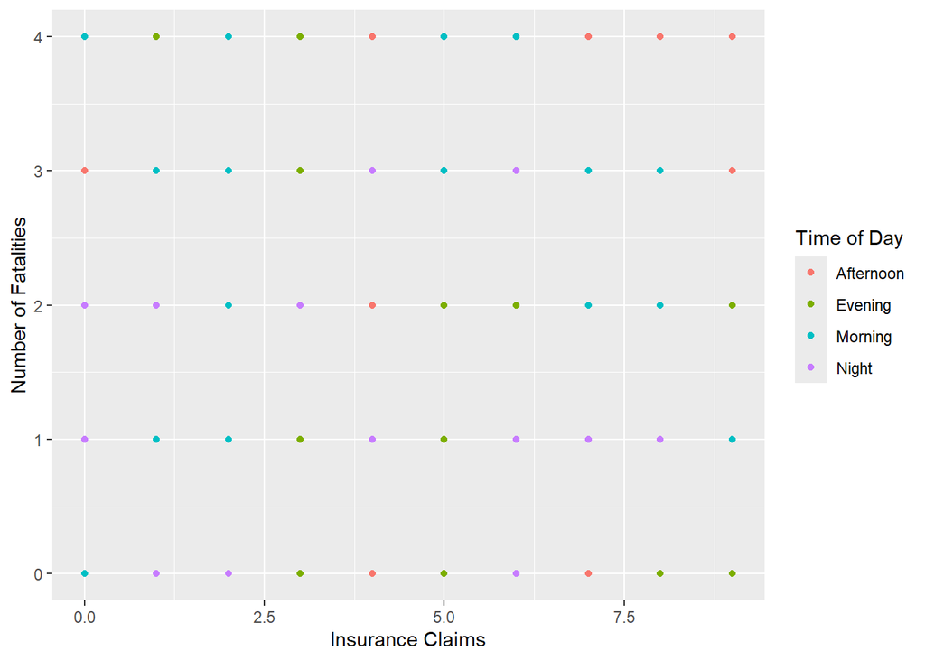

```r
ggplot(accidents, aes(`Insurance Claims`,`Number of Fatalities`,
                      color = `Time of Day`)) +
  geom_point()
```

After going through the quantitative variables in the dataset, I am unable to plot a visible relationship through preliminary data analysis techniques without data manipulation, so I decided to use the scatter plot above. The scatter plot above compares the Number of Fatalities to Insurance Claims, which are colored by the Time of Day that the accidents occurred during.

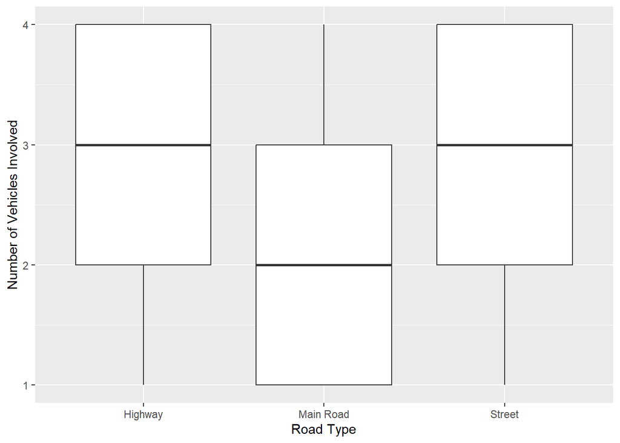

```r
ggplot(accidents, aes(`Road Type`,`Number of Vehicles Involved`)) +
  geom_boxplot()
```

Highways having a larger number of vehicles involved in accidents is expected since highways have higher speed limits, which delays reaction times as a result of drivers not being able to see far ahead if speeding. The large number of vehicles involved may be due to vehicle pileups in accidents or other disastrous actions as a result of speeding, reckless driving, or other causes.

I am surprised that streets would have an equally high number of vehicles involved in accidents to highways. The large number of vehicles involved may have resulted from blind spots along the streets that led to delays in reaction times of the driver. Since streets are usually narrower compared to highways and main roads, this may have factored into how much room drivers can maneuver there vehicles to avoid accidents, which may have led to a higher number of vehicles involved in accidents on this type of road.

From this plot, this leads me to the question: How does the vehicle’s condition affect the number of vehicles involved in accidents?

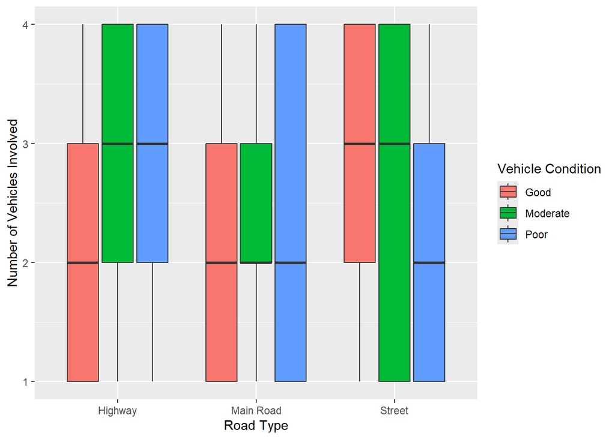

```r
ggplot(accidents, aes(`Road Type`,`Number of Vehicles Involved`,
                      fill = `Vehicle Condition`)) +
  geom_boxplot()
```

On average, vehicles in good condition are most likely to be involved in accidents on streets. On the other hand, vehicles of moderate condition are most likely to be involved in accidents on streets and highways while vehicles in poor condition are most likely to be involved in accidents on highways.

This also leads me to another question: How does the number of vehicles involved and their conditions differ between urban and rural areas?

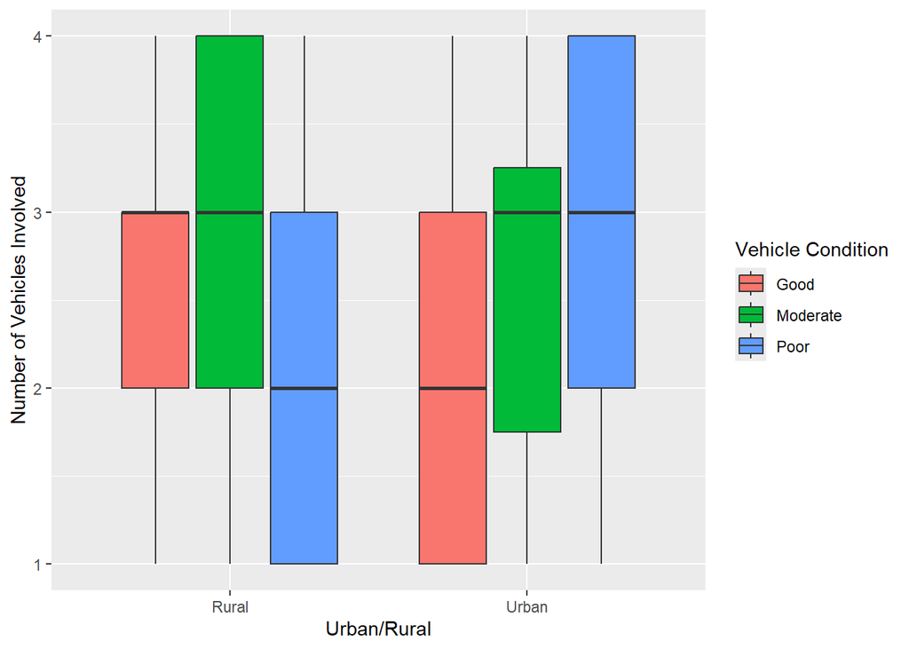

```r
ggplot(accidents, aes(`Urban/Rural`,`Number of Vehicles Involved`,
                      fill = `Vehicle Condition`)) +
  geom_boxplot()
```

On average, the vehicles of moderate condition are most likely to be involved in accidents in both urban and rural areas. Vehicles in good condition are most likely to be involved in rural areas while those in poor condition are most likely to be involved in urban areas.

The difference in poor vehicles may be due to the driving distances and the terrain in the different areas. Since the terrain in rural areas are harsher on vehicles compared to urban areas, drivers are more likely to keep good or moderate condition of their vehicles so that they may be able to drive through rural areas more easily. And as a result of a nicer driving environment that urban areas are more likely able to provide, the need to upkeep vehicle conditions is low.

## Data Manipulations

```r
sub_accidents <- filter(accidents, Country == "USA")
sub_accidents <- filter(sub_accidents, `Driver Age Group` == "18-25")

sub_accidents <- mutate(sub_accidents, `Fatalities to Injuries` = `Number of Fatalities`/`Number of Injuries`)
sub_accidents <- mutate(sub_accidents, `Total Fatalities and Injuries` = `Number of Fatalities` + `Number of Injuries`)

sub_accidents <- filter(sub_accidents, !is.infinite(`Fatalities to Injuries`))
sub_accidents <- filter(sub_accidents, !is.nan(`Fatalities to Injuries`))
```

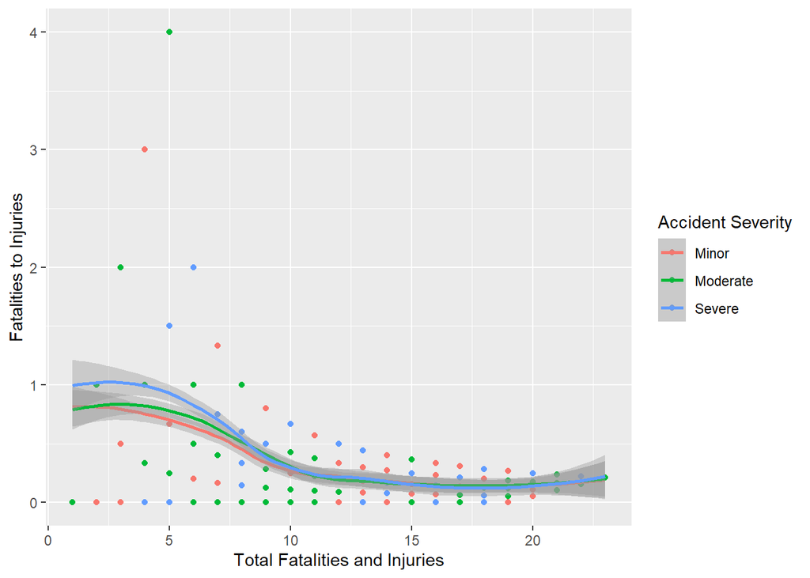

```r
ggplot(sub_accidents,aes(`Total Fatalities and Injuries`,`Fatalities to Injuries`,
                         color = `Accident Severity`)) +
  geom_point() +
  geom_smooth()
```

From the scatter plot above, it can be seen that severe accidents (blue), have the highest number of fatalities per injured out of the three levels of accident severity, which is expected. Accidents that are of moderate or minor severity are of similar values with moderate accidents being slightly higher.

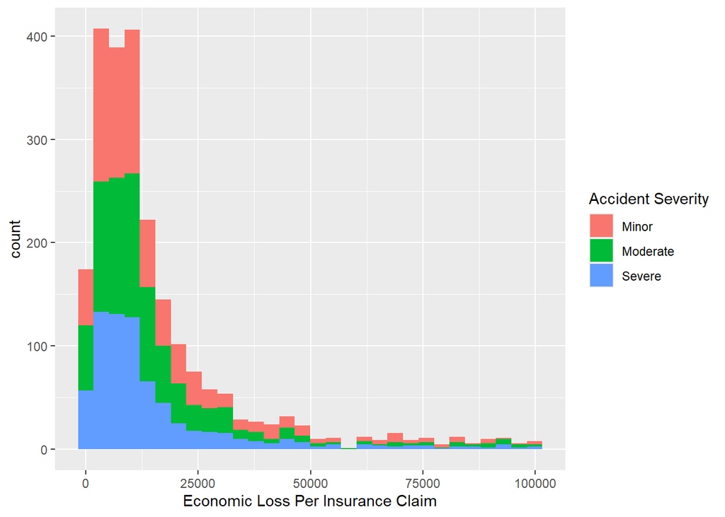

```r
sub_accidents <- mutate(sub_accidents, `Economic Loss Per Insurance Claim` = `Economic Loss`/`Insurance Claims`)
sub_accidents <- filter(sub_accidents, !is.infinite(`Economic Loss Per Insurance Claim`))

ggplot(sub_accidents, aes(`Economic Loss Per Insurance Claim`,fill = `Accident Severity`)) +
  geom_histogram()
```

## Statistical Analyses

```r
t_test_accident <- filter(accidents, (`Time of Day` == "Morning") | (`Time of Day` == "Evening"))
```

```r
t.test(`Emergency Response Time` ~ `Time of Day`, data = t_test_accident)
```

```
##
##  Welch Two Sample t-test
##
## data:  Emergency Response Time by Time of Day
## t = -0.95974, df = 65806, p-value = 0.3372
## alternative hypothesis: true difference in means between group Evening and group Morning is not equal to 0
## 95 percent confidence interval:
##  -0.3617927  0.1239444
## sample estimates:
## mean in group Evening mean in group Morning
##              32.52607              32.64500
```

```r
t.test(`Number of Injuries` ~ `Time of Day`, data = t_test_accident)
```

```
##
##  Welch Two Sample t-test
##
## data:  Number of Injuries by Time of Day
## t = 1.299, df = 65807, p-value = 0.1939
## alternative hypothesis: true difference in means between group Evening and group Morning is not equal to 0
## 95 percent confidence interval:
##  -0.02971313  0.14650079
## sample estimates:
## mean in group Evening mean in group Morning
##              9.529542              9.471148
```

```r
cor_accidents <- select(accidents,-Country,-Month,-`Day of Week`,-`Time of Day`,-Year,-`Urban/Rural`,-`Road Type`)
cor_accidents <-select(cor_accidents,-`Weather Conditions`, -`Driver Age Group`, -`Driver Gender`, -`Driver Fatigue`, -`Vehicle Condition`, -`Accident Severity`, -`Road Condition`,-`Accident Cause`, -`Region`)
```

```r
cor.test(cor_accidents$`Visibility Level`,cor_accidents$`Number of Vehicles Involved`)
```

```
##
##  Pearson's product-moment correlation
##
## data:  cor_accidents$`Visibility Level` and cor_accidents$`Number of Vehicles Involved`
## t = 0.1674, df = 131998, p-value = 0.8671
## alternative hypothesis: true correlation is not equal to 0
## 95 percent confidence interval:
##  -0.004933898  0.005855364
## sample estimates:
##          cor
## 0.0004607466
```

```r
cor(cor_accidents)
```

```
##                             Visibility Level Number of Vehicles Involved
## Visibility Level                1.0000000000                0.0004607466
## Number of Vehicles Involved     0.0004607466                1.0000000000
## Speed Limit                    -0.0025040614                0.0037587058
## Driver Alcohol Level            0.0024693479                0.0037672620
## Pedestrians Involved           -0.0037121673               -0.0049932506
## Cyclists Involved              -0.0004160691               -0.0018841504
## Number of Injuries              0.0009598316                0.0022336534
## Number of Fatalities           -0.0006372234                0.0033531380
## Emergency Response Time         0.0015006955                0.0019264071
## Traffic Volume                 -0.0024713527                0.0031682331
## Insurance Claims                0.0050500522               -0.0036211620
## Medical Cost                    0.0010658423               -0.0010917237
## Economic Loss                   0.0029692086                0.0003769546
## Population Density             -0.0001371371               -0.0043123523
##                               Speed Limit Driver Alcohol Level
## Visibility Level            -2.504061e-03         0.0024693479
## Number of Vehicles Involved  3.758706e-03         0.0037672620
## Speed Limit                  1.000000e+00         0.0007602813
## Driver Alcohol Level         7.602813e-04         1.0000000000
## Pedestrians Involved        -1.365066e-03         0.0050533446
## Cyclists Involved            1.922209e-03        -0.0007919098
## Number of Injuries          -1.117574e-03        -0.0012003787
## Number of Fatalities         6.205779e-04         0.0021147139
## Emergency Response Time      1.893000e-04        -0.0014532804
## Traffic Volume              -1.970046e-03         0.0034783191
## Insurance Claims             6.482653e-05        -0.0040820017
## Medical Cost                -1.013875e-03        -0.0019806061
## Economic Loss                3.492852e-04        -0.0052840566
## Population Density           1.393161e-03         0.0051155728
##                             Pedestrians Involved Cyclists Involved
## Visibility Level                   -0.0037121673     -0.0004160691
## Number of Vehicles Involved        -0.0049932506     -0.0018841504
## Speed Limit                        -0.0013650664      0.0019222089
## Driver Alcohol Level                0.0050533446     -0.0007919098
## Pedestrians Involved                1.0000000000      0.0028731462
## Cyclists Involved                   0.0028731462      1.0000000000
## Number of Injuries                 -0.0083765210      0.0004063487
## Number of Fatalities                0.0033462445      0.0051599800
## Emergency Response Time             0.0048271861      0.0003564624
```

[output cut: 50 more lines]

```
##                             Population Density
## Visibility Level                 -0.0001371371
## Number of Vehicles Involved      -0.0043123523
## Speed Limit                       0.0013931611
## Driver Alcohol Level              0.0051155728
## Pedestrians Involved              0.0009726117
## Cyclists Involved                 0.0037848166
## Number of Injuries                0.0020380723
## Number of Fatalities              0.0032667832
## Emergency Response Time           0.0016270355
## Traffic Volume                   -0.0018885846
## Insurance Claims                  0.0036080225
## Medical Cost                     -0.0010247586
## Economic Loss                     0.0001561422
## Population Density                1.0000000000
```

```r
accidents_regression <- lm(`Number of Fatalities` ~ `Number of Vehicles Involved`, data = accidents)
summary(accidents_regression)
```

```
##
## Call:
## lm(formula = `Number of Fatalities` ~ `Number of Vehicles Involved`,
##     data = accidents)
##
## Residuals:
##      Min       1Q   Median       3Q      Max
## -2.00180 -0.99755  0.00245  1.00669  2.01093
##
## Coefficients:
##                               Estimate Std. Error t value Pr(>|t|)
## (Intercept)                   1.984833   0.009536 208.150   <2e-16 ***
## `Number of Vehicles Involved` 0.004241   0.003481   1.218    0.223
## ---
## Signif. codes:  0 '***' 0.001 '**' 0.01 '*' 0.05 '.' 0.1 ' ' 1
##
## Residual standard error: 1.413 on 131998 degrees of freedom
## Multiple R-squared:  1.124e-05,  Adjusted R-squared:  3.668e-06
## F-statistic: 1.484 on 1 and 131998 DF,  p-value: 0.2231
```

Based on the linear regression test, less than 1% of Number of Fatalities is encompassed by the test. The p-value states that the relationship between Number of Fatalities and Number of Vehicles Involved is not very significant since it is greater than 0.10. The test also states that for every increase in vehicles in the accident, there is an increase of 0.004241 in fatalities. Otherwise, there is not much of a relationship between the two variables.